# Regression Models Course Project

Elizaveta Oginskaya

June 5, 2016

## Executive Summary

In this paper a set of car parameters was analysed to find whether MPG depends on transmission type:

- **Is an automatic or manual transmission better for MPG?** Yes, with 95% confidence level we can say that in general MPG is better for automatic transmission.
- **Quantify the MPG difference between automatic and manual transmissions.** Taking into consideration *only* transmission type automatic transmission allows to increase MPG by **7.24** miles per gallon. But there are two other significant parameters: *weight (wt)* and *1/4 mile time (qsec)*. Taking them into account as constant automatic transmission raise MPG only by average **4.30** miles per gallon.

As the report should only include 2 pages of results and annexes can only contain figures, please look at to .rmd file if you have any questions to the code.

## Exploring and Adjusting Data

The datasets contained 32 observations of 11 parameters of different car models (for more information on data please visit http://stat.ethz.ch/R-manual/R-devel/library/datasets/html/mtcars.html) *(Annex 1)*

```r
mtcars$cyl <- as.factor(mtcars$cyl)
mtcars$gear <- as.factor(mtcars$gear)
mtcars$carb <- as.factor(mtcars$carb)
```

The original dataset has all variables of numeric class. Before the main part of analysis variables `cyl`, `gear` and `carb` were converted into factors (the code is hidden, but available in *.rmd* file, look it up also for working dataset structure).

```r
str(mtcars)
```

```
## 'data.frame':    32 obs. of  11 variables:
##  $ mpg : num  21 21 22.8 21.4 18.7 18.1 14.3 24.4 22.8 19.2 ...
##  $ cyl : Factor w/ 3 levels "4","6","8": 2 2 1 2 3 2 3 1 1 2 ...
##  $ disp: num  160 160 108 258 360 ...
##  $ hp  : num  110 110 93 110 175 105 245 62 95 123 ...
##  $ drat: num  3.9 3.9 3.85 3.08 3.15 2.76 3.21 3.69 3.92 3.92 ...
##  $ wt  : num  2.62 2.88 2.32 3.21 3.44 ...
##  $ qsec: num  16.5 17 18.6 19.4 17 ...
##  $ vs  : num  0 0 1 1 0 1 0 1 1 1 ...
##  $ am  : num  1 1 1 0 0 0 0 0 0 0 ...
##  $ gear: Factor w/ 3 levels "3","4","5": 2 2 2 1 1 1 1 2 2 2 ...
##  $ carb: Factor w/ 6 levels "1","2","3","4",..: 4 4 1 1 2 1 4 2 2 4 ...
```

## Statistical Inference

To answer the first question, whether the MPG parameter depends on transmission type or not the t-test is taken, where the null hypothesis assume that the difference in MPG mean for cars with automatic transmission (factor = 1) and cars with manual transmission (factor = 0) is insignificant.

```r
t.test(mpg ~ am, data = mtcars)
```

```
##
##  Welch Two Sample t-test
##
## data:  mpg by am
## t = -3.7671, df = 18.332, p-value = 0.001374
## alternative hypothesis: true difference in means is not equal to 0
## 95 percent confidence interval:
##  -11.280194  -3.209684
## sample estimates:
## mean in group 0 mean in group 1
##        17.14737        24.39231
```

The 95% confidence interval doesn’t contain 0 and the p-value is very small, so the null hypothesis should be rejected in favor of the statement that means of two groups of cars are different.

## Regression Model

### Simple Regression Model

To evaluate the difference in MPG for automatic and manual transmissions the simple linear regression model was build. It assumes that MPG depends only on transmission type.

```r
fit1 <- lm(mpg ~ am, data = mtcars)
summary(fit1)$coef
```

```
##              Estimate Std. Error   t value     Pr(>|t|)
## (Intercept) 17.147368   1.124603 15.247492 1.133983e-15
## am           7.244939   1.764422  4.106127 2.850207e-04
```

```r
summary(fit1)$adj
```

```
## [1] 0.3384589
```

The model shows that the average MPG of cars with manual transmission equals **17.15** and automatic transmission increase MPG by **7.24** to **24.39**. P-values for the both coefficients are relatively small so the both coefficients are significant. Adjusted R-squared value is only 0.338, which means that the model explains only **33.8%** of mpg variation. *(Annex 2)*

### Finding Optimal Regression Model

```r
fit10 <- lm(mpg ~ ., data = mtcars)
summary(fit10)$adj
```

```
## [1] 0.7790215
```

For the search of the optimal model three more models were build: Regression model including all 10 regressors explains more variance of MPG - **77.9%**, but many of its coefficients have relatively large values and appears insignificant (see *.rmd* file)

```r
fits <- step(fit10, direction = 'both', k = log(nrow(mtcars)))
```

```
## Start:  AIC=101.32
## mpg ~ cyl + disp + hp + drat + wt + qsec + vs + am + gear + carb
##
##        Df Sum of Sq    RSS     AIC
## - carb  5   13.5989 134.00  87.417
## - gear  2    3.9729 124.38  95.428
## - cyl   2   10.9314 131.33  97.170
## - am    1    1.1420 121.55  98.157
## - qsec  1    1.2413 121.64  98.183
## - drat  1    1.8208 122.22  98.335
## - vs    1    3.6299 124.03  98.806
## - disp  1    9.9672 130.37 100.400
## <none>              120.40 101.321
## - wt    1   25.5541 145.96 104.014
## - hp    1   25.6715 146.07 104.040
##
## Step:  AIC=87.42
## mpg ~ cyl + disp + hp + drat + wt + qsec + vs + am + gear
##
##        Df Sum of Sq    RSS     AIC
## - gear  2    5.0215 139.02  81.662
## - cyl   2   12.5642 146.57  83.353
## - disp  1    0.9934 135.00  84.187
## - drat  1    1.1854 135.19  84.233
## - vs    1    3.6763 137.68  84.817
## - qsec  1    5.2634 139.26  85.184
## - am    1   11.9255 145.93  86.679
## <none>              134.00  87.417
## - wt    1   19.7963 153.80  88.360
## - hp    1   22.7935 156.79  88.978
## + carb  5   13.5989 120.40 101.321
##
## Step:  AIC=81.66
## mpg ~ cyl + disp + hp + drat + wt + qsec + vs + am
##
##        Df Sum of Sq    RSS    AIC
## - cyl   2   10.4247 149.45 77.045
## - drat  1    0.9672 139.99 78.418
## - disp  1    1.5483 140.57 78.551
## - vs    1    2.1829 141.21 78.695
```

[output cut: 72 more lines]

```
## Step:  AIC=67.17
## mpg ~ wt + qsec + am
##
##        Df Sum of Sq    RSS    AIC
## <none>              169.29 67.170
## - am    1    26.178 195.46 68.306
## + hp    1     9.219 160.07 68.844
## + disp  1     3.276 166.01 70.011
## + drat  1     1.400 167.89 70.370
## + vs    1     0.000 169.29 70.636
## + cyl   2     9.862 159.42 72.181
## + gear  2     0.185 169.10 74.067
## - qsec  1   109.034 278.32 79.614
## + carb  5    10.999 158.29 82.349
## - wt    1   183.347 352.63 87.187
```

```r
summary(fits)$coef
```

```
##              Estimate Std. Error   t value     Pr(>|t|)
## (Intercept)  9.617781  6.9595930  1.381946 1.779152e-01
## wt          -3.916504  0.7112016 -5.506882 6.952711e-06
## qsec         1.225886  0.2886696  4.246676 2.161737e-04
## am           2.935837  1.4109045  2.080819 4.671551e-02
```

The *stepwise* algorithm by *AIC* was implied to find an optimal fit model. The algorithm found the following best fit model:

```r
summary(fits)$call
```

```
## lm(formula = mpg ~ wt + qsec + am, data = mtcars)
```

All coefficients of the model except for the intercept turned out to be significant. The adjusted R-squared value for the models equals **0.834**.

On the base of previous model the last model was built by excluding the intercept:

```r
fitn <- lm(mpg ~ wt + qsec + am - 1, data = mtcars)
summary(fitn)$coef
```

```
##       Estimate Std. Error   t value     Pr(>|t|)
## wt   -3.185455  0.4827586 -6.598442 3.128844e-07
## qsec  1.599823  0.1021276 15.664944 1.091522e-15
## am    4.299519  1.0241147  4.198279 2.329423e-04
```

This model has all coefficients significant and explains **98.6%** of MPG variance.

```r
summary(fitn)
```

```
##
## Call:
## lm(formula = mpg ~ wt + qsec + am - 1, data = mtcars)
##
## Residuals:
##     Min      1Q  Median      3Q     Max
## -3.8820 -1.5401 -0.4246  1.6623  4.1711
##
## Coefficients:
##      Estimate Std. Error t value Pr(>|t|)
## wt    -3.1855     0.4828  -6.598 3.13e-07 ***
## qsec   1.5998     0.1021  15.665 1.09e-15 ***
## am     4.2995     1.0241   4.198 0.000233 ***
## ---
## Signif. codes:  0 '***' 0.001 '**' 0.01 '*' 0.05 '.' 0.1 ' ' 1
##
## Residual standard error: 2.497 on 29 degrees of freedom
## Multiple R-squared:  0.9871, Adjusted R-squared:  0.9858
## F-statistic:   741 on 3 and 29 DF,  p-value: < 2.2e-16
```

## Nested models

```r
as.matrix(anova(fit1, fitn))
```

```
##   Res.Df      RSS Df Sum of Sq       F       Pr(>F)
## 1     30 720.8966 NA        NA      NA           NA
## 2     29 180.8323  1  540.0643 86.6099 3.284554e-10
```

## Residuals Diagnostics

```r
lvrg <- hatvalues(fitn)
tail(sort(lvrg))
```

```
##  Cadillac Fleetwood       Toyota Corona            Merc 230
##           0.1498921           0.1543131           0.1621136
##   Chrysler Imperial Lincoln Continental       Maserati Bora
##           0.1736978           0.1756953           0.1880244
```

```r
infl <- dfbetas(fitn)
tail(sort(infl[,3]))
```

```
## Porsche 914-2  Lotus Europa      Fiat 128       Valiant Toyota Corona
##     0.1382957     0.1980752     0.1998664     0.2770478     0.3645146
##      Merc 230
##     0.5567496
```

## Annexes

### Annex 1: Data Pairs

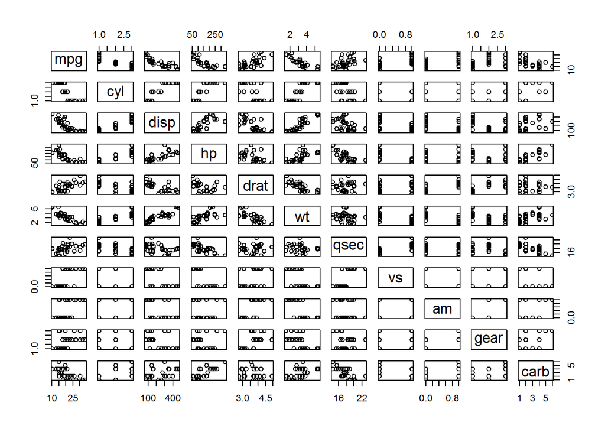

```r
par(mfrow = c(1, 1))
pairs(mtcars)
```

### Annex 2: MPG by transmission type:

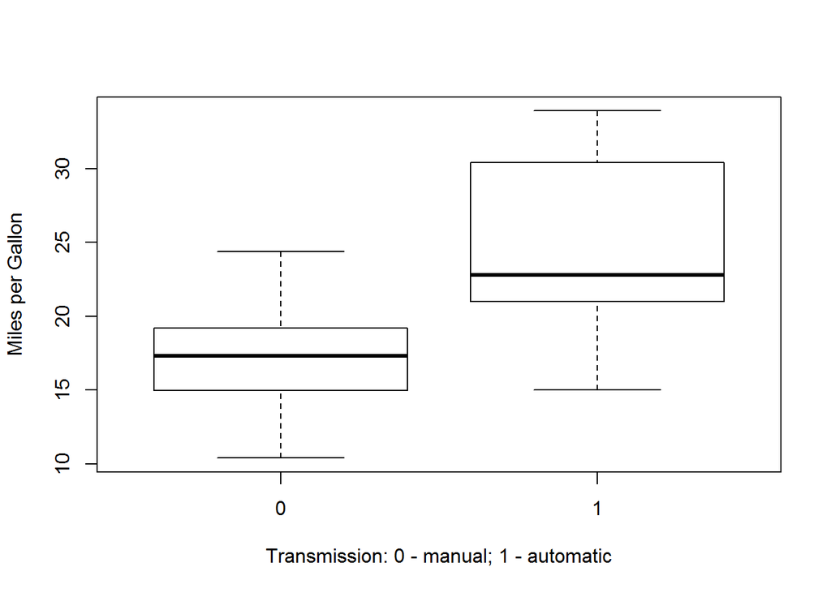

```r
par(mfrow = c(1, 1))
boxplot(mpg ~ am, data = mtcars, xlab = 'Transmission: 0 - manual; 1 - automatic', ylab = 'Miles per Gallon')
```

### Annex 3: Residuals Diagnostics

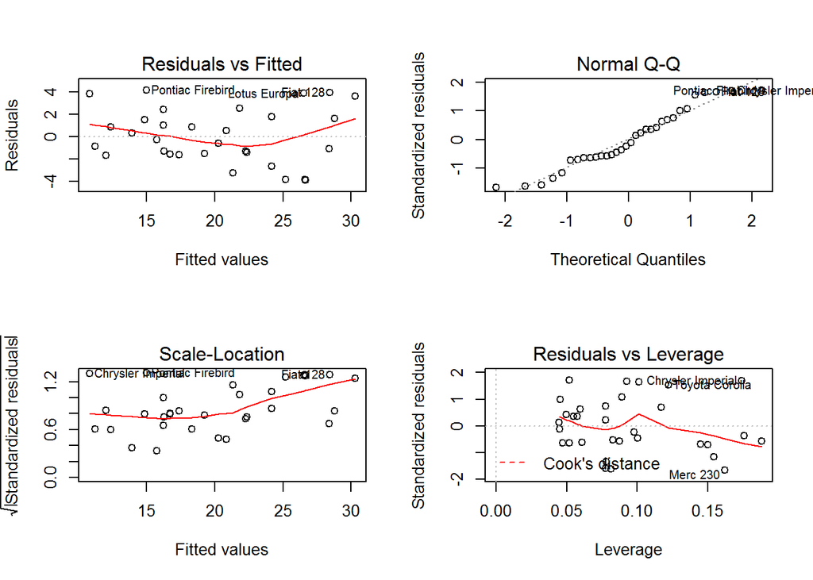

```r
par(mfrow = c(2, 2))
plot(fitn)
```